# Inferring Microbial Networks in Different Soil Conditions

Dexter Chen

10/10/2024

## Preprocessing

The raw dataset soil_**sample_gr2.rds** consists of three subsets: **otu_table**, **tax_table** and **sam_data**.

```
- Firstly, remove taxa not seen more than 3 times in at least 20% of the samples. Due to the missing taxonomy information, only keep until the family level.

- Split by soil conditions and filter 0 counts taxas

- Keep only shared taxas in 2 conditions
```

```r
library(phyloseq)
library(SPRING)
library(SpiecEasi)
library(JGL)
library(EstimateGroupNetwork)
library(SpiecEasi)
library(igraph)
library(caret)     # For confusionMatrix function
library(pROC)      # For ROC and AUC calculation
library(MLmetrics) # For F1 Score, MCC
library(ggraph)
library(igraph)
library(tidyverse)
library(tibble)
library(RColorBrewer)
data_soil_raw <- readRDS("data\\soil_sample_gr2.rds")
data_soil = filter_taxa(data_soil_raw, function(x) sum(x > 3) > (0.2*length(x)), TRUE)
otu_Ab <- t(otu_table(data_soil))
otu_tax <- tax_table(data_soil)[,1:5]
soil_info <- sample_data(data_soil)[, "Soil_Type"]
otu_Ab_naural <- otu_Ab[soil_info == "Forest",
                        colSums(otu_Ab[soil_info == "Forest",]) != 0]
otu_Ab_potting <- otu_Ab[soil_info == "Potting",
                        colSums(otu_Ab[soil_info == "Potting",]) != 0]
shared_taxa <- intersect(colnames(otu_Ab_naural), colnames(otu_Ab_potting))
otu_Ab_naural <- otu_Ab_naural[, shared_taxa]
otu_Ab_potting <- otu_Ab_potting[, shared_taxa]
head(otu_Ab_naural,n = c(5,5))
```

```
## OTU Table:          [5 taxa and 5 samples]
##                      taxa are columns
##           bASV63 bASV75 bASV82 bASV83 bASV91
## B1_16S         0      0      0      0      0
## B2_16S         0      0      0     96      0
## B2915_16S      0     75    121      0      0
## B2916_16S      0      0      0      0      0
## B3_16S         0     13      0      0     34
```

```r
head(otu_Ab_potting,n = c(5,5))
```

```
## OTU Table:          [5 taxa and 5 samples]
##                      taxa are columns
##            bASV63 bASV75 bASV82 bASV83 bASV91
## EK4_16S        99     78      0    109     65
## EK5_16S         0     28      0    150     22
## EK5917_16S      0     51      0      0     19
## EK5918_16S      0     34     77     28     96
## K7_16S        106     59    148     65     53
```

## Synthesize simulated networks

### Normalization and scaling

Now, normalize and scale the aboundance data by default. Firstly, calculate the sum of each row (representing the sequencing depth for each sample) and finds the minimum depth across all samples. Then, normalize each row to sum to 1 and multiply the normalized values by the minimum depth. Finally, round the scaled values to integers. This method aims to adjust the data to a common scale while preserving the relative abundance of features within each sample.

### mClr and correlation matrix

The second part of the function performs modifed centre logratio using **SPRING** and estimate the correlation matrix using **mixedCCA**.

Finally, apply joint graphical lasso and generate the true nerwork using the **EstimateGroupNetwork**

```r
preprocess_and_estimate_network <- function(data_list, labels = NULL,  nlambda1 = 10, nlambda2 = 10){
  norm_to_total <- function(x) x / sum(x)
  common_scaling <- function(data) {
    depths <- rowSums(data)
    data_normalized <- t(apply(data, 1, norm_to_total))
    common_depth <- min(depths)
    data_common_scaled <- round(data_normalized * common_depth)
    return(data_common_scaled)
  }
  processed_data_list <- lapply(data_list, function(data) {
    scaled_data <- common_scaling(data)
    mclr_data <- mclr(scaled_data) # Using SPRING's mclr
    Kcor <- mixedCCA::estimateR(mclr_data, type = "trunc", method = "approx", tol = 1e-6, verbose = FALSE)$R
    return(Kcor)
  })
  n_samples <- sapply(data_list, nrow)
  Res <- EstimateGroupNetwork(
    processed_data_list,
    inputType = "list.of.covariance.matrices",
    n = n_samples,
    labels = labels, # Pass labels directly
    nlambda1 = nlambda1,
    nlambda2 = nlambda2,
    truncate = 1e-10,
    criterion = 'aic'
  )

  return(Res)
}
data_list <- list(naural = otu_Ab_naural, potting = otu_Ab_potting)
network_results <- preprocess_and_estimate_network(data_list, labels = shared_taxa)
network_naural <- network_results$naural
network_potting <- network_results$potting
head(network_naural,n = c(5,5))
```

```
##            bASV63     bASV75      bASV82     bASV83     bASV91
## bASV63 0.00000000 0.02099509  0.08409208  0.0000000  0.0000000
## bASV75 0.02099509 0.00000000  0.13090305  0.0000000  0.0000000
## bASV82 0.08409208 0.13090305  0.00000000  0.0000000 -0.1212391
## bASV83 0.00000000 0.00000000  0.00000000  0.0000000 -0.0150565
## bASV91 0.00000000 0.00000000 -0.12123912 -0.0150565  0.0000000
```

```r
head(network_potting,n = c(5,5))
```

```
##             bASV63      bASV75      bASV82      bASV83      bASV91
## bASV63  0.00000000  0.02915651  0.08415086  0.00000000 -0.03423791
## bASV75  0.02915651  0.00000000 -0.06611216 -0.11952737  0.00000000
## bASV82  0.08415086 -0.06611216  0.00000000  0.00000000 -0.16272915
## bASV83  0.00000000 -0.11952737  0.00000000  0.00000000  0.03914469
## bASV91 -0.03423791  0.00000000 -0.16272915  0.03914469  0.00000000
```

## Visualize on the network

### Edge weights distribution

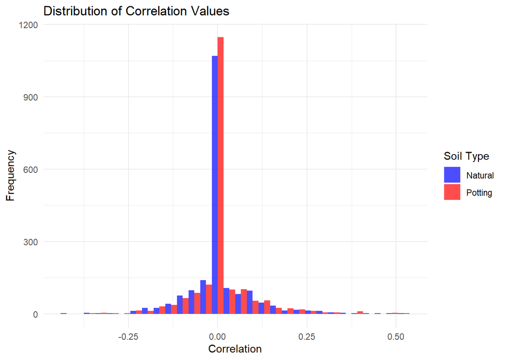

```r
cor_values_naural <- as.vector(network_naural)
cor_values_potting <- as.vector(network_potting)
cor_df <- data.frame(
  correlation = c(cor_values_naural, cor_values_potting),
  group = factor(rep(c("Natural", "Potting"), each = length(cor_values_naural)))
)
hist_plot <- ggplot(cor_df, aes(x = correlation, fill = group)) +
  geom_histogram(position = "dodge", bins = 30, alpha = 0.7) +
  scale_fill_manual(values = c("Natural" = "blue", "Potting" = "red")) +
  theme_minimal() +
  labs(title = "Distribution of Correlation Values",
       x = "Correlation",
       y = "Frequency",
       fill = "Soil Type")
print(hist_plot)
```

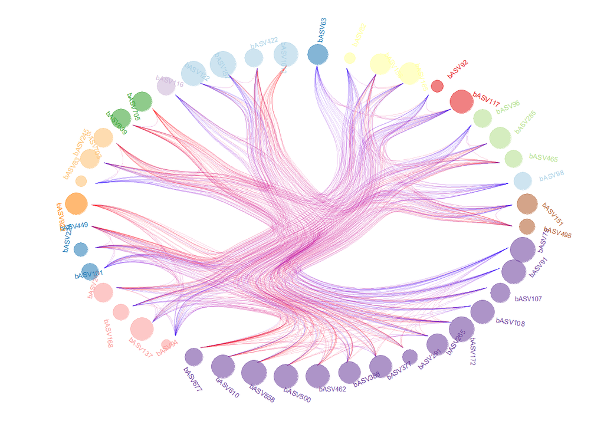

```r
otu_tax_df <- otu_tax %>%
as.data.frame() %>%
tibble::rownames_to_column("OTU") %>%
dplyr::select(OTU, everything())

pairs <- list(
c("Kingdom", "Phylum"),
c("Phylum", "Class"),
c("Class", "Order"),
c("Order", "Family"),
c("Family", "OTU"))
create_edges <- function(pair, data)
{
    from <- data[[pair[1]]]
    to <- data[[pair[2]]]
    data.frame(from = from, to = to)
}
edges <- unique(do.call(rbind, lapply(pairs, create_edges, data = otu_tax_df[otu_tax_df$OTU %in% shared_taxa, ])))
lower_tri <- lower.tri(network_naural, diag = FALSE)
non_zero <- which(lower_tri & network_naural != 0, arr.ind = TRUE)
connect <- data.frame(
from = rownames(network_naural)[non_zero[, 1]],
to = colnames(network_naural)[non_zero[, 2]],
score = network_naural[non_zero])
vertices  <-  data.frame(
name = unique(c(as.character(edges$from), as.character(edges$to))) ,
value = runif(length(unique(c(as.character(edges$from), as.character(edges$to))))))
vertices$group  <-  edges$from[ match( vertices$name, edges$to ) ]
vertices$id <- NA
myleaves <- which(is.na(match(vertices$name, edges$from)))
vertices$value[myleaves] <- colSums(network_naural) / sum(network_naural)
nleaves <- length(myleaves)
vertices$id[myleaves] <- seq(1:nleaves)
vertices$angle <- 90 - 360 * vertices$id / nleaves
vertices$angle <- ifelse(vertices$angle < -90, vertices$angle+180, vertices$angle)
vertices$hjust <- ifelse( vertices$angle < -90, 1, 0)
mygraph <- igraph::graph_from_data_frame( edges, vertices=vertices )
from  <-  match( connect$from, vertices$name)
to  <-  match( connect$to, vertices$name)
p <- ggraph(mygraph, layout = 'dendrogram', circular = TRUE) +
geom_conn_bundle(data = get_con(from = from, to = to), alpha=0.2, width=0.1, aes(colour = after_stat(index))) +
scale_edge_colour_gradient(low = "red", high = "blue") +
geom_node_text(aes(x = x*1.15, y=y*1.15, filter = leaf, label=name, angle = angle, hjust=hjust, colour=group), size=2, alpha=1) +
geom_node_point(aes(filter = leaf, x = x*1.07, y=y*1.07, colour=group, size=value, alpha=0.2)) +
scale_colour_manual(values= rep(brewer.pal(14,"Paired") , 30)) +
scale_size_continuous(range = c(0.1,10) ) +
theme_void() +
theme(
    legend.position="none",
    plot.margin=unit(c(0,0,0,0),"cm"),
) +
expand_limits(x = c(-1.3, 1.3), y = c(-1.3, 1.3))
print(p)
```

## Evaluate synthesized dataset Now, synthesize 10 dataset based on the origin/true aboundance data.

```r
true_adj_naural <- (network_naural !=0)*1
true_adj_potting <- (network_potting !=0)*1
set.seed(10010)
synthesize_scaled_data <- function(dat, net)
  {
    graph <- (net != 0)*1     # SpiecEasi::make_graph('cluster', dat$n_OTUs, dat$n_edge)
    attr(graph, "class") <- "graph"
    Prec <- SpiecEasi::graph2prec(graph)
    Cor <- cov2cor(SpiecEasi::prec2cov(Prec))
    X <- SpiecEasi::synth_comm_from_counts(dat, mar = 2, distr = 'zinegbin', Sigma = Cor, n = nrow(dat))
    return(X)
  }
Sim_list <- list()
for (i in 1:10)
  {
    Sim_list[[i]] <- list(
      naural = synthesize_scaled_data(otu_Ab_naural, network_naural),
      potting = synthesize_scaled_data(otu_Ab_potting, network_potting)
    )
  }
Res_sim <- list()
for (i in 1:10)
  {
    Res_sim[[i]] <- preprocess_and_estimate_network(Sim_list[[i]], labels = shared_taxa)
  }
Sim_adj <- list()
for (i in 1:10)
  {
    Sim_adj[[i]] <- list(
      naural = (Res_sim[[i]]$naural !=0)*1,
      potting = (Res_sim[[i]]$potting !=0)*1
    )
  }
calculate_mcc <- function(tp, tn, fp, fn)
  {
    numerator <- (tp * tn) - (fp * fn)
    denominator <- sqrt((tp + fp) * (tp + fn) * (tn + fp) * (tn + fn))

    # If the denominator is 0, return 0 to avoid NaN errors
    if (denominator == 0) {
      return(0)
    } else {
      return(numerator / denominator)
    }
  }
calculate_metrics <- function(true_adj, sim_adj)
  {
    # Flatten the matrices into vectors (upper triangular part, excluding diagonal)
    true_edges <- as.vector(true_adj[upper.tri(true_adj)])
    sim_edges <- as.vector(sim_adj[upper.tri(sim_adj)])

    # Confusion matrix
    cm <- confusionMatrix(as.factor(sim_edges), as.factor(true_edges), positive = "1")
    tn <- as.numeric(cm$table[1,1]) #true negatives
    fp <- as.numeric(cm$table[1,2]) #false positives
    fn <- as.numeric(cm$table[2,1]) #false negatives
    tp <- as.numeric(cm$table[2,2]) #true positives

    # Calculate TPR, FPR, Precision, Recall
    tpr <- tp / (tp + fn)  # Sensitivity / Recall
    fpr <- fp / (fp + tn)  # 1 - Specificity
    precision <- tp / (tp + fp)
    recall <- tpr

    # Calculate ROC and AUC
    roc_obj <- roc(true_edges, sim_edges)
    auc <- as.numeric(auc(roc_obj)) # plot here

    # F1 Score
    f1 <- F1_Score(sim_edges, true_edges)

    # MCC (Matthews correlation coefficient)
    mcc <- calculate_mcc(tp, tn, fp, fn)

    # Return metrics as a list
    return(list(TPR = tpr, FPR = fpr, Precision = precision, Recall = recall,
                F1 = f1, AUC = auc, MCC = mcc))
  }
confusion_results <- lapply(1:10, function(i)
    {
    # Calculate metrics for both natural and potting
    natural_metrics <- calculate_metrics(true_adj_naural, Sim_adj[[i]]$naural)
    potting_metrics <- calculate_metrics(true_adj_potting, Sim_adj[[i]]$potting)
    # Return both results as a named list
    return(list(natural = natural_metrics, potting = potting_metrics))
    } )
results_df <- do.call(rbind, lapply(confusion_results, as.data.frame))
head(results_df,n = c(5,5))
```

```
##   natural.TPR natural.FPR natural.Precision natural.Recall natural.F1
## 1   0.5526882   0.4885655         0.5223577      0.5526882  0.5262032
## 2   0.5468085   0.4936975         0.5223577      0.5468085  0.5182796
## 3   0.5162602   0.5242291         0.5162602      0.5162602  0.4757709
## 4   0.5411559   0.4880000         0.6280488      0.5411559  0.4632087
## 5   0.5796178   0.4610526         0.5548780      0.5796178  0.5511302
```

## Plot barplots to see the simulated matrices

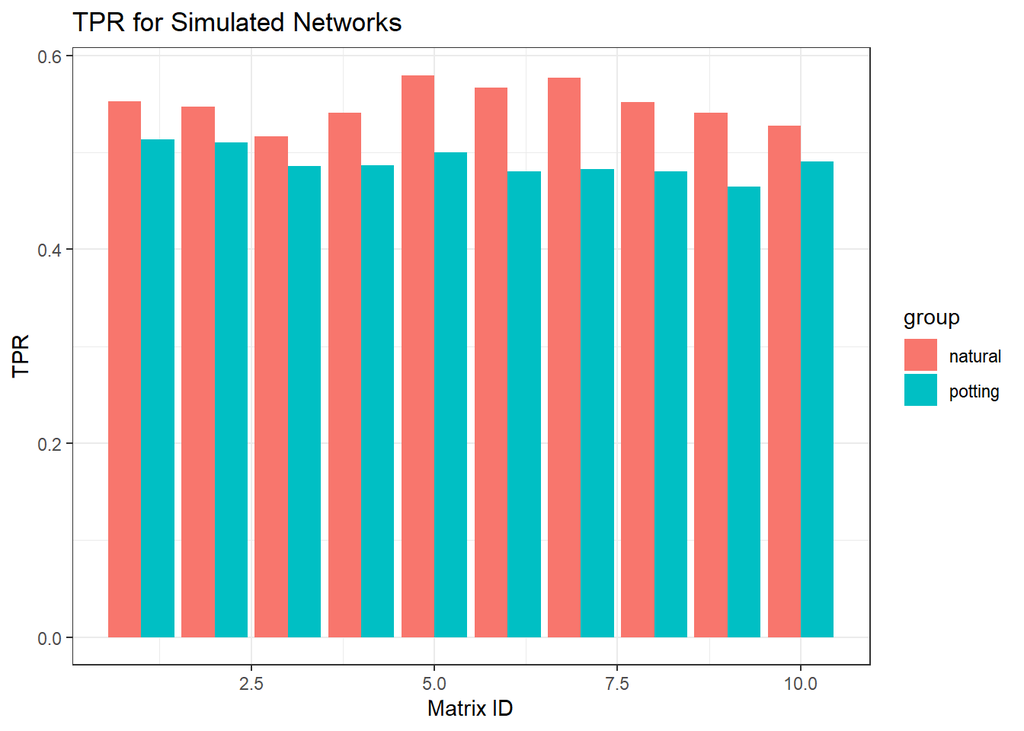

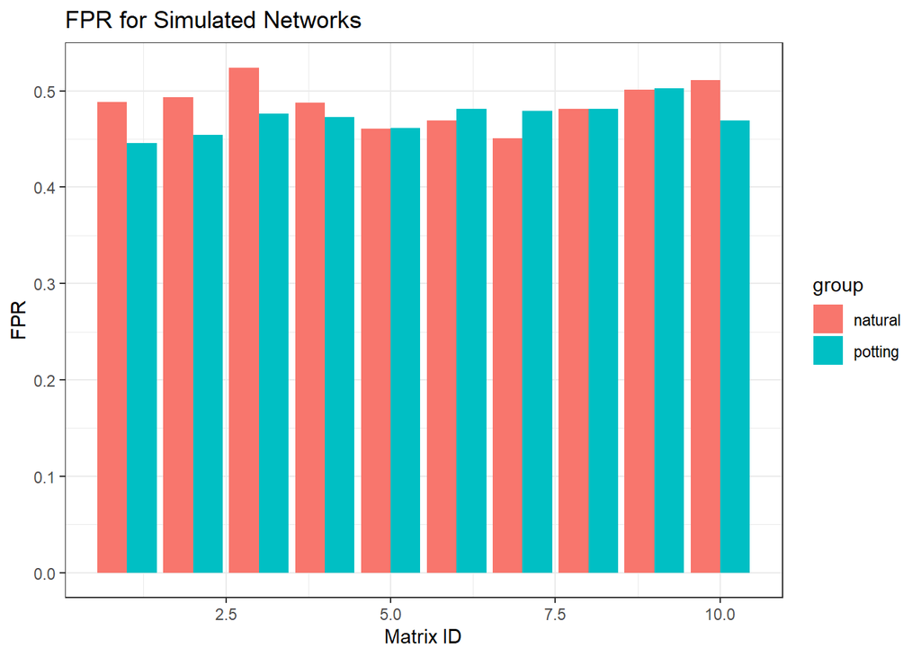

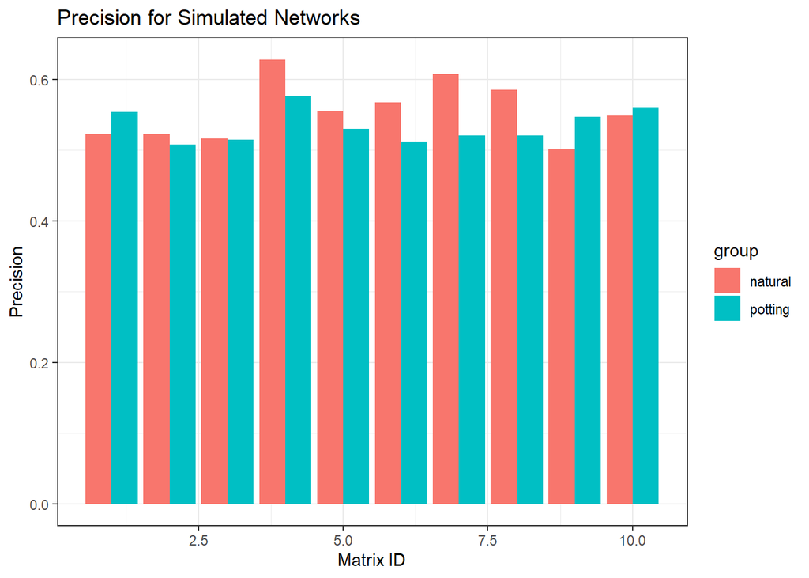

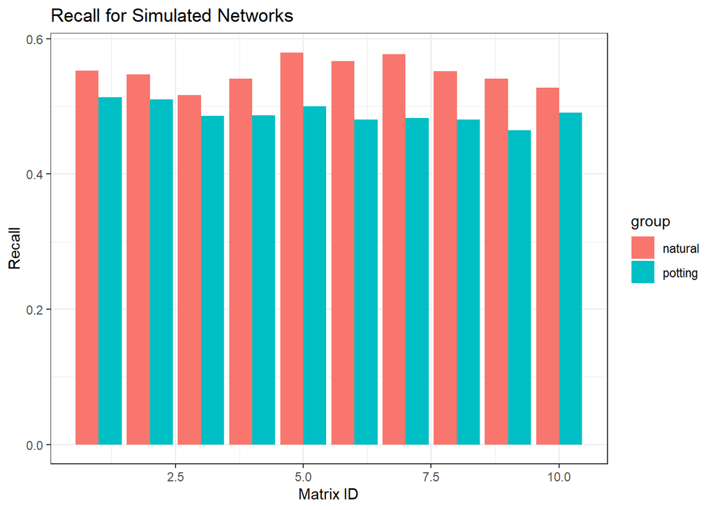

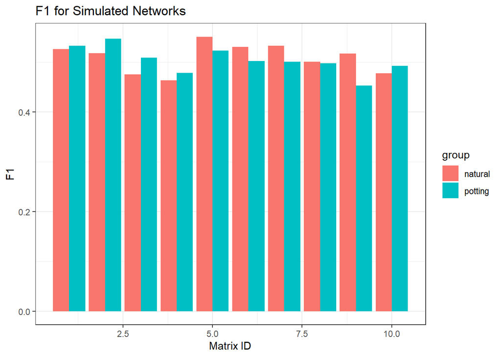

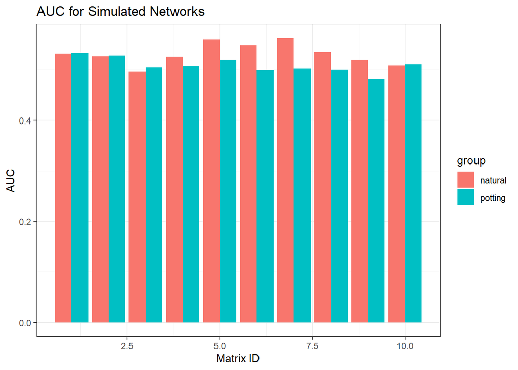

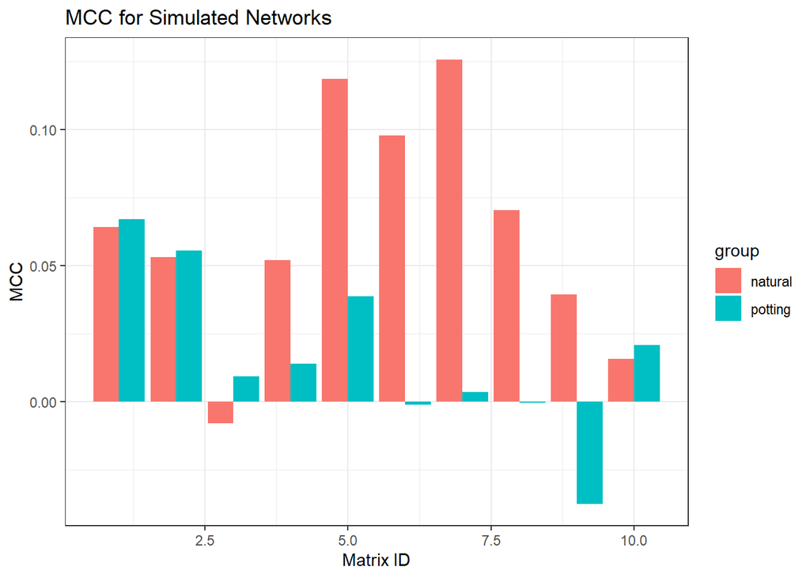

```r
results_df_long <- results_df %>%
  dplyr::select(starts_with("natural.") | starts_with("potting.")) %>%
  tidyr::pivot_longer(cols = everything(),
               names_to = c("group", "metric"),
               names_sep = "\\.",
               values_to = "value") %>%
  dplyr::mutate(matrix_id = rep(1:10, each = 14)) # Add matrix ID

# Create separate plots for each metric
for (metric_name in unique(results_df_long$metric)) {
    plot_data <- results_df_long %>%
        dplyr::filter(metric == metric_name)

    p <- ggplot(plot_data, aes(x = matrix_id, y = value, fill = group)) +
        geom_bar(stat = "identity", position = "dodge") +
        labs(title = paste(metric_name, "for Simulated Networks"),
            x = "Matrix ID",
            y = metric_name) +
        theme_bw()
    print(p)
  #ggsave(paste0(metric_name, "_plot.png"), p)
}
```